# Introducción a deaR

25 de enero de 2019

## ¿Qué es DEA?

DEA es una técnica de programación matemática que permite la construcción de una superficie envolvente, frontera eficiente o función de producción empírica, a partir de los datos disponibles del conjunto de DMUs objeto de estudio.

Las DMUs que determinan la envolvente son denominadas DMUs eficientes y aquellas que no permanecen sobre la misma son consideradas DMUs ineficientes.

DEA permite la evaluación de la eficiencia **relativa** de cada una de las DMUs.

## Caracterización de los modelos DEA

- Tipología de medida de eficiencia: modelos radiales, modelos no radiales, etc.
- Orientación del modelo.
- Tipología de rendimientos a escala.

## El paquete deaR

- Paquete de [R](http://www.r-project.org)
- Desarrollado con el IDE [Rstudio](http://www.rstudio.com)
- No sólo es un conjunto de funciones que permite resolver los modelos DEA más usuales
- Proporciona una infraestructura de datos flexible que permite incorporar nuevos modelos de forma sencilla

## Modelos disponibles

### **Modelos radiales**

| Modelo | Orientación | Retornos a escala | Función |
| --- | --- | --- | --- |
| Radial básico | IO/OO/DIR | CRS/VRS/NIRS/NDRS/GRS | model_basic |
| Multiplicativo | IO/OO | CRS/VRS/NIRS/NDRS/GRS | model_multiplier |
| Free disposal hull | IO/OO/DIR | VRS | model_fdh |

## Modelos disponibles

### **Modelos no radiales**

| Modelo | Orientación | Retornos a escala | Función |
| --- | --- | --- | --- |
| No radial básico | IO/OO | CRS/VRS/NIRS/NDRS/GRS | model_nonradial |
| Aditivo | NA | CRS/VRS/NIRS/NDRS/GRS | model_additive |
| Preference Structure | IO/OO | CRS/VRS/NIRS/NDRS/GRS | model_deaps |
| Slack-based model | IO/OO/NO | CRS/VRS/NIRS/NDRS/GRS | model_sbmeff |
| Eficiencia de beneficios | NA | CRS/VRS/NIRS/NDRS/GRS | model_profit |

## Modelos disponibles

### **Modelos de supereficiencia**

[output not shown]

## Modelos disponibles

### **Modelos fuzzy**

| Modelo | Orientación | Retornos a escala | Función |
| --- | --- | --- | --- |
| Modelo Guo-Tanaka | IO/OO | CRS | modelfuzzy_guotanaka |
| Modelo Kao-Liu | Todos | Todos | modelfuzzy_kaoliu |
| Modelo Posibilístico | IO/OO/DIR | CRS/VRS/NIRS/NDRS/GRS | modelfuzzy_possibilistic |

## Modelos disponibles

### **Otros modelos**

| Modelo | Orientación | Retornos a escala | Función |
| --- | --- | --- | --- |
| Índice de Malmquist | IO/OO | VSR | malmquist_index |
| Bootstrap básico | IO/OO | CRS/VRS | bootstrap_basic |
| Eficiencias cruzadas | IO/OO | CRS/VRS | cross_efficiency |
| Eficiencias cruzadas fuzzy | IO/OO | CRS | cross_efficiency_fuzzy |

## Instalar deaR

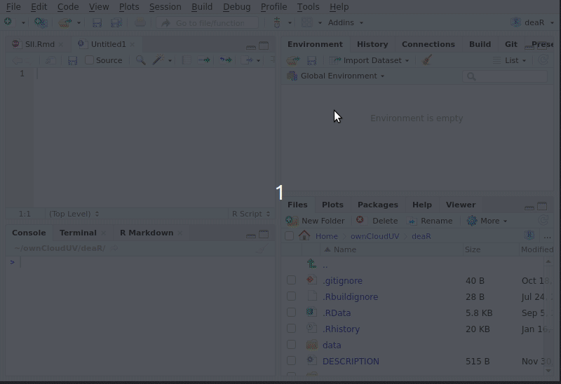

## Workflow

## Flujo de trabajo

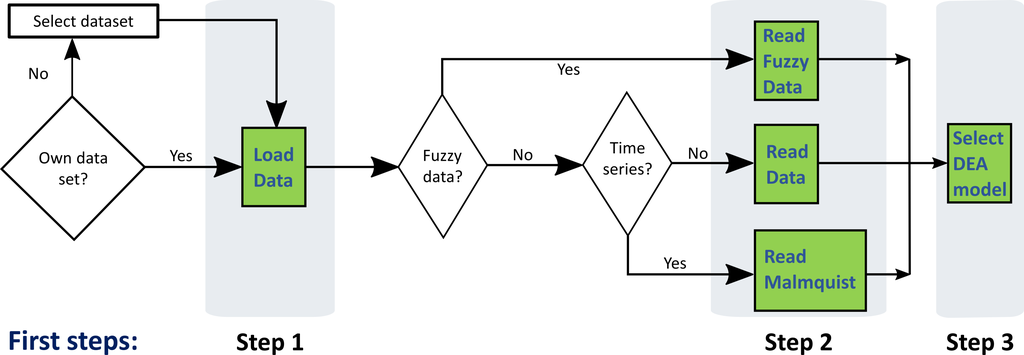

## Importar desde Excel

[figure not shown]

## Leer los datos

- La tabla de datos hay que convertirlo en una lista **deadata**
- Usaremos la función **read_data**
- Hay que determinar las DMUs, los inputs / outputs y otras opciones

| Company | Assets | Equity | Employees | Revenue | Profit |
| --- | --- | --- | --- | --- | --- |
| Mitsubishi | 91920.6 | 10950.0 | 36000 | 184365.2 | 346.2 |
| Mitsui | 68770.9 | 5553.9 | 80000 | 181518.7 | 314.8 |
| Itochu | 65708.9 | 4271.1 | 7182 | 169164.6 | 121.2 |
| General Motors | 217123.4 | 23345.5 | 709000 | 168828.6 | 6880.7 |

## Leer los datos

```r
Fortune500 <- as.data.frame(Fortune500)
misdatos <- read_data(datadea = Fortune500, ni = 3, no = 2)
```

- **misdatos** es una lista de tipo **deadata** conteniendo

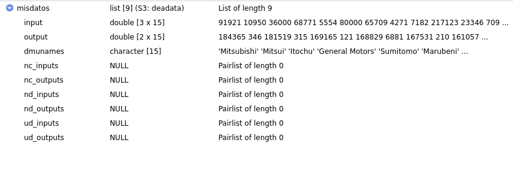

## Aplicamos el modelo…

### Modelo básico (input orientado)

\[ \begin{aligned} \min_{\theta,\,\mathbf{\lambda}}&\quad\theta \\ s.a.:&\\ &\sum_{j=1}^n\lambda_j x_{ij}\leq \theta x_{io},\qquad &i = 1,\ldots,m\\ &\sum_{j=1}^n\lambda_j y_{rj}\geq y_{ro},\qquad &r = 1,\ldots,s\\ &\lambda_j\geq 0\qquad& j = 1,\ldots,n \end{aligned} \]

## Modelo básico con deaR

```r
result <- model_basic(misdatos)
```

## Extracción de resultados

- Parciales
  - **efficiencies**
  - **lambdas**
  - **slacks**
  - **targets**
  - **multipliers**
  - **rts**
  - **references**
- Generales
  - **summary**
  - **plot**

## Nos vamos al ordenador…

## Otras opciones de datos

## I/O No controlables

- Ej. 2º input y 1er ouput no controlables

```r
misdatos <- read_data(datadea = Fortune500, ni = 3, no = 2, nc_inputs = 2, nc_outputs = 1)
```

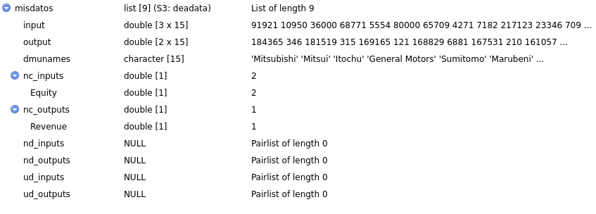

## Ejemplo (modelo básico)

\[ \begin{aligned} \min_{\theta,\,\mathbf{\lambda}}&\quad\theta \\ s.a.:&\\ &\sum_{j=1}^n\lambda_j x_{ij}\leq \theta x_{io},\qquad &i \in IC\\ &\sum_{j=1}^n\lambda_j y_{rj}\geq y_{ro},\qquad &r \in OC\\ &\lambda_j\geq 0& j = 1,\ldots,n \end{aligned} \]

\[ \begin{aligned} &\\ &\\ &\\ &\sum_{j=1}^n\lambda_j x_{ij}= x_{io},\qquad &i \not\in IC\\ &\sum_{j=1}^n\lambda_j y_{rj}= y_{ro},\qquad &r \not\in OC\\ \end{aligned} \]

```r
result <- model_basic(misdatos)
```

## I/O No discreccionales

- Ej. 1er y 3er inputs y 2º ouput no discrecionales

```r
misdatos <- read_data(datadea = Fortune500, ni = 3, no = 2,
                      nd_inputs = c(1,3), nd_outputs = 2)
```

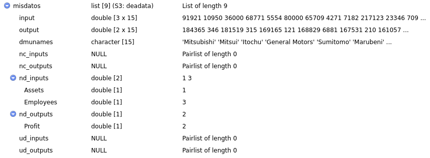

## Ejemplo (modelo básico)

\[ \begin{aligned} \min_{\theta,\,\mathbf{\lambda}}&\quad \theta \\ s.a.:&\\ &\sum_{j=1}^n\lambda_j x_{ij}\leq \theta x_{io},&i \in ID\\ &\sum_{j=1}^n\lambda_j y_{rj}\geq y_{ro}&r \in OD\\ &\lambda_j\geq 0& j = 1,\ldots,n \end{aligned} \]

\[ \begin{aligned} &\\ &\\ &\sum_{j=1}^n\lambda_j x_{ij} \leq x_{io}, &i \not\in ID\\ &\sum_{j=1}^n\lambda_j y_{rj}\geq y_{ro},&r \not\in OD\\ \end{aligned} \]

## I/O No deseables (o bad)

- Se transforman los inputs/outputs no deseables (normalmente son outputs)
- Ejemplo: Huan-Bian, 2007. 2 Inputs, 3 ouputs, output 3 no deseable

```r
huan <- read_data(Hua_Bian_2007, ni = 2, no = 3, ud_outputs = 3)
results1 <- model_basic(huan, orientation = "oo", rts = "vrs")
results2 <- model_basic(huan, orientation = "oo", rts = "vrs", vtrans_o = 1500)
```

## Otras opciones generales de los modelos

## Otras opciones

- Orientación del modelo (**orientation**)
  - Input / Output / Direccional / No orientado
- Retornos a escala (**rts**)
  - CRS, VRS, NIRS, NDRS, GRS
- DMUs a evaluar (**dmu_eval**)
- DMUs de referencia (**dmu_ref**)
- 2ª etapa (**max_slack**) con pesos

## Índice de Malmquist

## Índice de Malmquist

- Tenemos datos en distintos periodos de tiempo
- Vemos la evolución de las eficiencias
- Los datos están formateados de manera diferente:
  - Tablas horizontales
  - Tablas verticales
- La función **read_malmquist** general una lista de deadata

## Tabla horizontal

| DMUs | Capital2005 | Labor2005 | GIOV2005 | Capital2006 | Labor2006 | GIOV2006 |
| --- | --- | --- | --- | --- | --- | --- |
| Beijing | 12829.79 | 116.97 | 6946.07 | 14244.40 | 117.36 | 8210.00 |
| Tianjin | 6347.92 | 122.17 | 6774.10 | 7129.02 | 116.33 | 8527.70 |
| Hebei | 9473.70 | 292.21 | 11008.12 | 11250.95 | 303.35 | 13489.80 |
| Shanxi_1 | 7045.09 | 213.20 | 4850.91 | 8865.50 | 220.59 | 5902.84 |
| Neimenggu | 4595.89 | 83.70 | 2995.59 | 5605.92 | 90.72 | 4140.05 |
| Liaoning | 11902.12 | 276.55 | 10814.51 | 14140.89 | 303.02 | 14167.95 |

## Tabla vertical

|  | DMUs | Period | Capital | Labor | GIOV |
| --- | --- | --- | --- | --- | --- |
| 1 | Beijing | 2005 | 12829.79 | 116.97 | 6946.07 |
| 2 | Tianjin | 2005 | 6347.92 | 122.17 | 6774.10 |
| … | … | … | … | … | …. |
| 31 | Sinkiang | 2005 | 2837.00 | 46.70 | 2102.53 |
| 32 | Beijing | 2006 | 14244.40 | 117.36 | 8210.00 |
| 33 | Tianjin | 2006 | 7129.02 | 116.33 | 8527.70 |
| … | … | … | … | … | …. |

## Lectura de datos (Tabla horizontal)

- Hace falta indicar el número de periodos, el número de inputs/outputs

```r
ejemplo_malmquist <- read_malmquist(datadea = Economy,
                                nper = 5,
                                arrangement = "horizontal",
                                ni = 2,
                                no = 1)
```

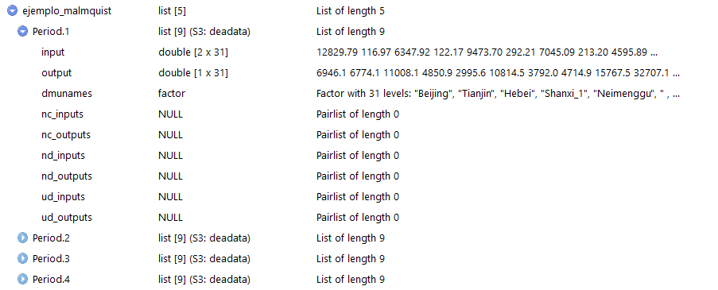

## Lectura de datos (Tabla vertical)

- Hace falta indicar la columna que contiene la información temporal, los inputs/outputs

```r
ejemplo_malmquist2 <- read_malmquist(datadea = EconomyLong,
                                percol = 2,
                                arrangement = "vertical",
                                ni = 2,
                                no = 1)
```

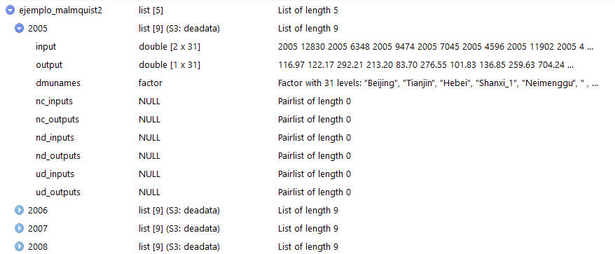

## Ejecutamos el modelo

```r
MI <- malmquist_index(ejemplo_malmquist2)
resumen <- summary(MI)
knitr::kable(resumen$Results[1:5,])
```

| Period | DMU | ec | tc | pech | sech | mi |
| --- | --- | --- | --- | --- | --- | --- |
| 2006 | Beijing | 0.9904260 | 0.9185664 | 1 | 0.9904260 | 0.9097720 |
| 2006 | Tianjin | 0.9049332 | 0.9383294 | 1 | 0.9049332 | 0.8491254 |
| 2006 | Hebei | 0.9502866 | 0.9329661 | 1 | 0.9502866 | 0.8865852 |
| 2006 | Shanxi_1 | 0.8854319 | 0.9407446 | 1 | 0.8854319 | 0.8329653 |
| 2006 | Neimenggu | 0.9483924 | 0.9369410 | 1 | 0.9483924 | 0.8885877 |

## Más resultados

```r
  knitr::kable(resumen$means_by_period)
```

| Period | ec | tc | pech | sech | mi |
| --- | --- | --- | --- | --- | --- |
| 2006 | 0.9500551 | 0.9350165 | 1 | 0.9500551 | 0.8883172 |
| 2007 | 0.9627391 | 0.9052274 | 1 | 0.9627391 | 0.8714978 |
| 2008 | 0.9440146 | 0.9441444 | 1 | 0.9440146 | 0.8912862 |
| 2009 | 1.0063403 | 0.8777664 | 1 | 1.0063403 | 0.8833317 |

## Y más todavía…

```r
  knitr::kable(head(resumen$means_by_dmu))
```

| DMU | ec | tc | pech | sech | mi |
| --- | --- | --- | --- | --- | --- |
| Anhui | 0.9809305 | 0.9054903 | 1 | 0.9809305 | 0.8882230 |
| Beijing | 0.9925625 | 0.9174540 | 1 | 0.9925625 | 0.9106305 |
| Chongqing | 1.0149624 | 0.9054903 | 1 | 1.0149624 | 0.9190386 |
| Fujian | 0.9991211 | 0.9114593 | 1 | 0.9991211 | 0.9106582 |
| Gansu | 0.9154485 | 0.9054903 | 1 | 0.9154485 | 0.8289297 |
| Guangdong | 1.0000000 | 0.9939756 | 1 | 1.0000000 | 0.9939756 |

## Eficiencia cruzada

## Eficiencia cruzada

```r
data_example <- read_data(datadea = Golany_Roll_1989,
                          dmus = 1,
                          inputs = 2:4,
                          outputs = 5:6)
result <- cross_efficiency(data_example,
                           orientation = "io",
                           rts = "crs",
                           selfapp = TRUE)
```

Doyle, J.; Green, R. (1994). *“Efficiency and cross efficiency in DEA: derivations, meanings and the uses”*, Journal of Operational Research Society, **45(5)**, 567–578. DOI: 10.2307/2584392

## Eficiencia cruzada (resultados)

**Método arbitrario**

|  | DMU_1 | DMU_2 | DMU_3 | DMU_4 |
| --- | --- | --- | --- | --- |
| DMU_1 | 0.6810811 | 0.7179487 | 0.5973333 | 0.8129032 |
| DMU_2 | 0.5518519 | 0.8333333 | 0.6196078 | 0.9000000 |
| DMU_3 | 0.6666667 | 0.8333333 | 0.6274510 | 0.8571429 |
| DMU_4 | 0.5444444 | 0.8312500 | 0.6176471 | 0.9000000 |

## Eficiencia cruzada (resultados)

**Método II (Agresivo)**

|  | DMU_1 | DMU_2 | DMU_3 | DMU_4 |
| --- | --- | --- | --- | --- |
| DMU_1 | 0.6810811 | 0.7179487 | 0.5973333 | 0.8129032 |
| DMU_2 | 0.5518519 | 0.8333333 | 0.6196078 | 0.9000000 |
| DMU_3 | 0.6666667 | 0.8333333 | 0.6274510 | 0.8571429 |
| DMU_4 | 0.5444444 | 0.8312500 | 0.6176471 | 0.9000000 |

## Eficiencia cruzada (resultados)

**Método II (Benevolente)**

|  | DMU_1 | DMU_2 | DMU_3 | DMU_4 |
| --- | --- | --- | --- | --- |
| DMU_1 | 0.6810811 | 0.7179487 | 0.5973333 | 0.8129032 |
| DMU_2 | 0.5518519 | 0.8333333 | 0.6196078 | 0.9000000 |
| DMU_3 | 0.6666667 | 0.8333333 | 0.6274510 | 0.8571429 |
| DMU_4 | 0.5444444 | 0.8312500 | 0.6176471 | 0.9000000 |

## Modelos Fuzzy

## Números fuzzy

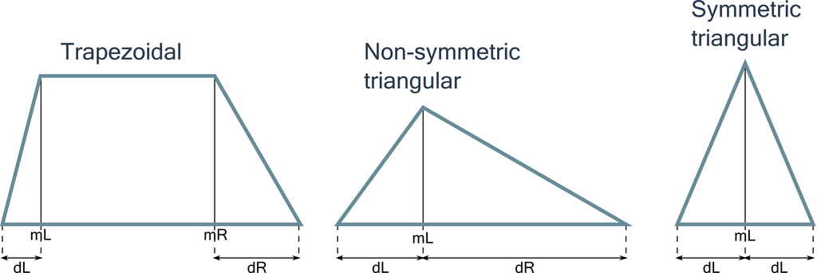

## Lectura de datos (Leon2003)

| DMU | x | alpha | y | beta |
| --- | --- | --- | --- | --- |
| A | 3.0 | 2.0 | 3.0 | 1.00 |
| B | 4.0 | 0.5 | 2.5 | 1.00 |
| C | 4.5 | 1.5 | 6.0 | 1.00 |
| D | 6.5 | 0.5 | 4.0 | 1.25 |
| E | 7.0 | 2.0 | 5.0 | 0.50 |
| F | 8.0 | 0.5 | 3.5 | 0.50 |

## Lectura de datos (Triangular simétrico)

```r
data_exampleL <- read_data_fuzzy(datadea = Leon2003, dmus = 1, inputs.mL = 2, inputs.dL = 3,
                                outputs.mL = 4, outputs.dL = 5)
```

## Lectura de datos (Kao_Liu_2003)

| Library | Patronage | Collections | Personel | Expenditures | Buildings | Services | beta3_l | beta3_u | beta5_l | beta5_u |
| --- | --- | --- | --- | --- | --- | --- | --- | --- | --- | --- |
| Library_01 | 0.28 | 0.32 | 0.20 | 0.41 | 0.48 | 0.79 | 0.0 | 0.00 | 0.00 | 0.00 |
| Library_02 | 0.16 | 0.57 | 0.22 | 0.50 | 1.00 | 0.55 | 0.0 | 0.00 | 0.00 | 0.00 |
| Library_03 | 1.00 | 1.00 | 1.00 | 1.00 | 0.86 | 0.98 | 0.0 | 0.00 | 0.00 | 0.00 |
| Library_04 | 0.53 | 0.67 | 0.81 | 0.74 | 0.36 | 0.92 | 0.0 | 0.00 | 0.00 | 0.00 |
| Library_05 | 0.02 | 0.10 | 0.08 | 0.15 | 0.03 | 0.57 | 0.0 | 0.00 | 0.00 | 0.00 |
| Library_06 | 0.56 | 0.58 | 0.50 | 0.63 | 0.68 | 1.00 | 0.0 | 0.00 | 0.00 | 0.00 |
| Library_07 | 0.24 | 0.41 | 0.34 | 0.58 | 0.34 | 0.76 | 0.0 | 0.00 | 0.00 | 0.00 |
| Library_08 | 0.01 | 0.37 | 0.04 | 0.11 | 0.05 | 0.41 | 0.0 | 0.00 | 0.00 | 0.00 |
| Library_09 | 0.12 | 0.06 | 0.11 | 0.13 | 0.14 | 0.65 | 0.0 | 0.00 | 0.00 | 0.00 |
| Library_10 | 0.82 | 0.32 | 0.41 | 0.62 | 0.79 | 0.87 | 0.0 | 0.00 | 0.00 | 0.00 |
| Library_11 | 0.57 | 0.70 | 0.37 | 0.21 | 0.41 | 0.71 | 0.0 | 0.00 | 0.00 | 0.00 |
| Library_12 | 0.20 | 0.09 | 0.11 | 0.23 | 0.24 | 0.64 | 0.0 | 0.00 | 0.00 | 0.00 |
| Library_13 | 0.33 | 0.25 | 0.36 | 0.19 | 0.28 | 0.72 | 0.0 | 0.00 | 0.00 | 0.00 |
| Library_14 | 0.35 | 0.30 | 0.31 | 0.49 | 0.44 | 0.71 | 0.0 | 0.00 | 0.00 | 0.00 |
| Library_15 | 0.30 | 0.32 | 0.13 | 0.44 | 0.21 | 0.68 | 0.0 | 0.00 | 0.00 | 0.00 |
| Library_16 | 0.20 | 0.27 | 0.23 | 0.40 | 0.51 | 0.56 | 0.0 | 0.00 | 0.00 | 0.00 |
| Library_17 | 0.47 | 0.26 | 0.37 | 0.30 | 0.62 | 0.71 | 0.0 | 0.00 | 0.00 | 0.00 |
| Library_18 | 0.19 | 0.24 | 0.23 | 0.30 | 0.36 | 0.52 | 0.0 | 0.00 | 0.00 | 0.00 |
| Library_19 | 0.14 | 0.21 | 0.14 | 0.21 | 0.16 | 0.53 | 0.0 | 0.00 | 0.00 | 0.00 |
| Library_20 | 0.66 | 0.28 | 0.46 | 0.45 | 0.59 | 0.70 | 0.0 | 0.00 | 0.00 | 0.00 |
| Library_21 | 0.46 | 0.23 | 0.28 | 0.28 | 0.40 | 0.59 | 0.0 | 0.00 | 0.00 | 0.00 |
| Library_22 | 0.45 | 0.25 | 0.30 | 0.52 | 0.32 | 0.69 | 0.0 | 0.00 | 0.28 | 0.31 |
| Library_23 | 0.69 | 0.42 | 0.31 | 0.41 | 0.54 | 0.69 | 0.0 | 0.00 | 0.28 | 0.31 |
| Library_24 | 0.72 | 0.44 | 0.27 | 0.41 | 0.18 | 0.47 | 0.3 | 0.59 | 0.00 | 0.00 |

## Lectura de datos (Triangular asimétrico)

```r
data_exampleKL <- read_data_fuzzy(datadea = Kao_Liu_2003, dmus = 1,
                                inputs.mL = 2,
                                outputs.mL = 3:7,
                                outputs.dL = c(NA, NA, 8, NA, 10),
                                outputs.dR = c(NA, NA, 9, NA, 11))
```

## Corremos el modelo (Kao-Liu)

- Se puede ejecutar sobre cualquier otro modelo crisp
- Considera el mejor y el peor caso
- Devuelve eficiencias para ciertos \(\alpha\)-cortes

```r
result <- modelfuzzy_kaoliu(data_exampleL,
                            kaoliu_modelname = "basic",
                            orientation = "io",
                            rts = "crs",
                            alpha = c(0,0.25,0.5,0.75,1))
```

## Resultados (Peor caso)

|  | 0 | 0.25 | 0.5 | 0.75 | 1 |
| --- | --- | --- | --- | --- | --- |
| A | 0.171 | 0.250 | 0.361 | 0.519 | 0.750 |
| B | 0.083 | 0.160 | 0.269 | 0.360 | 0.469 |
| C | 0.208 | 0.373 | 0.599 | 0.907 | 1.000 |
| D | 0.098 | 0.178 | 0.286 | 0.367 | 0.462 |
| E | 0.125 | 0.218 | 0.339 | 0.429 | 0.536 |
| F | 0.088 | 0.149 | 0.225 | 0.274 | 0.328 |

## Resultados (Mejor caso)

|  | 0 | 0.25 | 0.5 | 0.75 | 1 |
| --- | --- | --- | --- | --- | --- |
| A | 1.00 | 1.000 | 1.000 | 1.000 | 0.750 |
| B | 1.00 | 0.961 | 0.764 | 0.602 | 0.469 |
| C | 1.00 | 1.000 | 1.000 | 1.000 | 1.000 |
| D | 1.00 | 0.864 | 0.706 | 0.574 | 0.462 |
| E | 1.00 | 1.000 | 0.835 | 0.668 | 0.536 |
| F | 0.64 | 0.544 | 0.462 | 0.390 | 0.328 |

## Próximamente… Shiny!!!